# MADA 8060E Project

Trends in New HIV Diagnoses in the US, 2008-2020

Author

Nicole Luisi

Published

April 7, 2023

# 1 Summary/Abstract

# 2 Introduction

## 2.1 General Background Information

Previous research by [Chapin-Bardales et al. (2017)](https://doi.org/10.1016/j.annepidem.2017.04.002) evaluated trends in AIDS diagnosis rates by race/ethnicity between 1984-2013.

(Chapin-Bardales, Rosenberg, & Sullivan, 2017) (Patrick Sean Sullivan et al., 2020) (Patrick S. Sullivan et al., 2018) (Fields, Copeland, & Hopkins, 2021) (Bosh, Hall, Eastham, & Daskalakis, 2021) (McCree et al., 2019) (Young & Zhang, 2018)

## 2.2 Description of data and data source

**Data Source**:

*Note: New diagnoses data are currently only available through 2020 on AIDSVu and CDC Atlas. If 2021-2022 data are not available by the time the analysis needs to be completed, the analysis will be temporarily restricted to 2012-2020.*

- HIV New Diagnoses: [AIDSVu](https://aidsvu.org/)
- Google Trend data for search term “HIV”: [Google Trends](https://trends.google.com/)

(Patrick Sean Sullivan et al., 2020)

**Analysis**:

- Rate (per 100,000) of new HIV diagnoses by age, gender, and race/ethnicity (national, regional)
- Rate ratios for new HIV diagnoses by age, gender, and race/ethnicity (national, regional)
- Average annual percent change (AAPC) for incidence (calculated using [Joinpoint Regression Software (Version 4.9.1.0)](https://surveillance.cancer.gov/help/joinpoint/tech-help/citation))
- Predictions for Black-White and Hispanic-White rate ratios by state, using Google Trend search data for the term “HIV”

## 2.3 Questions/Hypotheses to be addressed

This analysis will evaluate national and regional trends in HIV new diagnoses between 2008-2020 by sex, age, and race/ethnicity. Black-White and Hispanic-White rate ratios will also be predicted for 2022 based on Google Trend results for search term “HIV”.

# 3 Methods

## 3.1 Data aquisition

Data files were downloaded from [AIDSVu](https://aidsvu.org/) and placed in `data/raw_data/AIDSVu` sub-folders. The new diagnosis files consist of one xlsx file per year for each level (national, regional, state, etc.). For [Google Trends](https://trends.google.com/), annual estimates for search term “HIV” were downloaded for each state.

## 3.2 Data import and cleaning

The `processingcode.R` file includes the following steps:

- Read in xlsx data files and combine all years for each level
- Subset variables of interest and rename variables so all levels are consistent
- View/explore data
- Calculate new rate ratio variables for subgroups (White=ref)
- Prepare combined national and regional file with all variables

The `analysis.qmd` file includes the following steps:

- Read in result data from external Joinpoint analyses
- Clean and combine Joinpoint analysis results
- View/explore data
- Create tables and plots of results

## 3.3 Statistical analysis

Rate ratios for race/ethnicity were calculated by dividing the new diagnosis rate for each group by the new diagnosis rate for the reference group (non-Hispanic White).

[Joinpoint Regression Software (Version 4.9.1.0)](https://surveillance.cancer.gov/help/joinpoint/tech-help/citation) was used to test for significant joinpoints (years) to identify trends in new diagnoses rates, nationally and regionally, by sex, age, and race/ethnicity. Trends for rate ratios were also used to assess disparities by race/ethnicity over time. For Joinpoint analyses, the maximum number of joinpoints was set to 3, and standard errors were auto-calculated by the tool under the heteroscedasticity assumption. The average annual percent changes (AAPCs) from 2008-2020 were also calculated for all subsets.

Google Trend data for search term “HIV” was downloaded for each state and year between 2016-2020. These data were used in linear models to predict not yet released 2022 Black-White and Hispanic-White rate ratios based on Google Trend data for 2022.

# 4 Results

## 4.1 Descriptive analysis

Figure 1 shows line plot for national new diagnosis rates by sex.

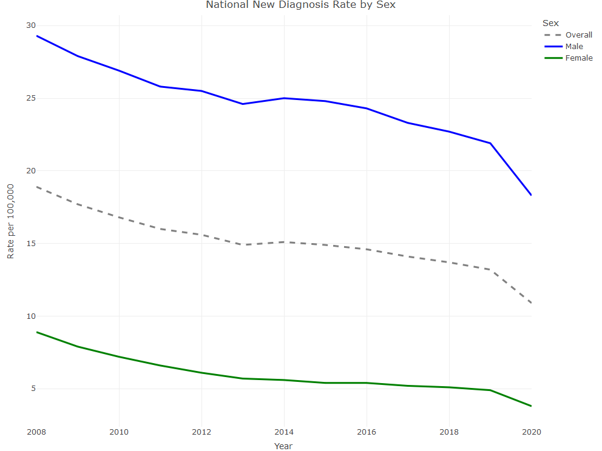

Figure 1: National new diagnosis rates by sex

Figure 2 shows line plot for national new diagnosis rates by age group.

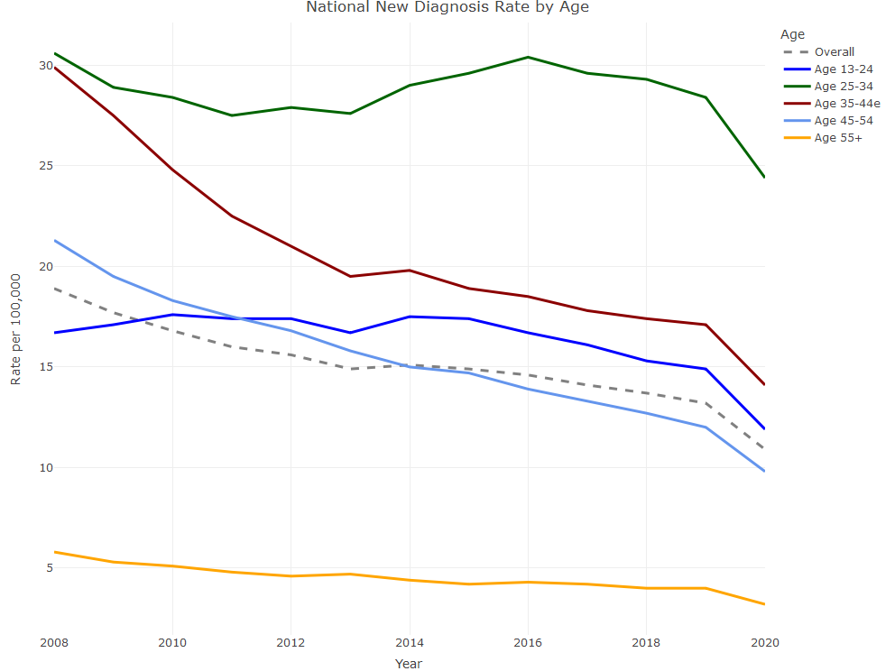

Figure 2: National new diagnosis rates by age group

Figure 3 shows line plot for national new diagnosis rates by race/ethnicity.

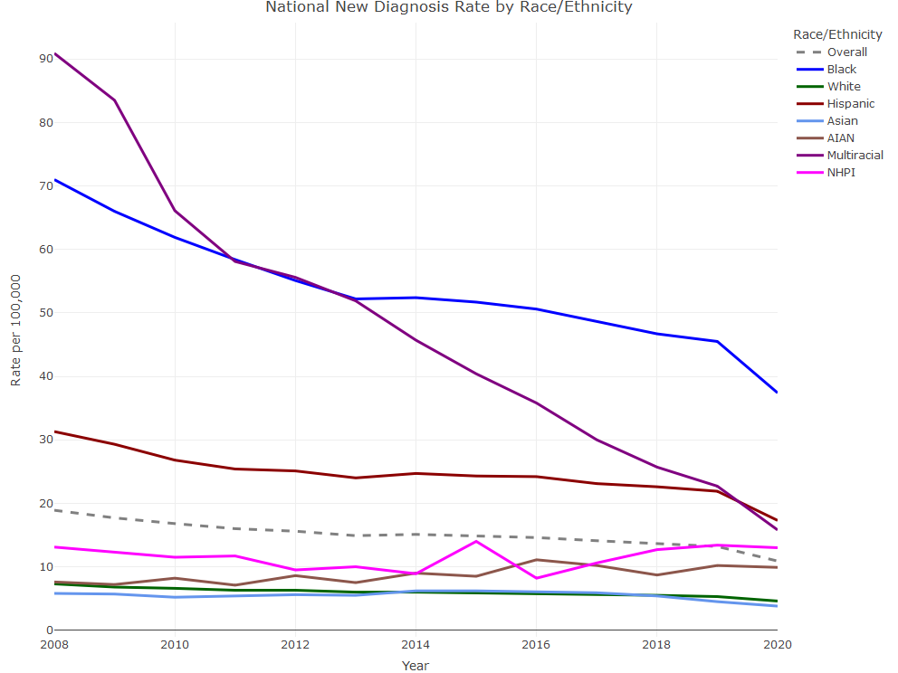

Figure 3: National new diagnosis rates by race/ethnicity

Figure 4 shows a bubble plot comparing regional new diagnosis (log) rates by race/ethnicity. The color represents race/ethnicity and the size of the point represents the log of the new diagnosis rate.

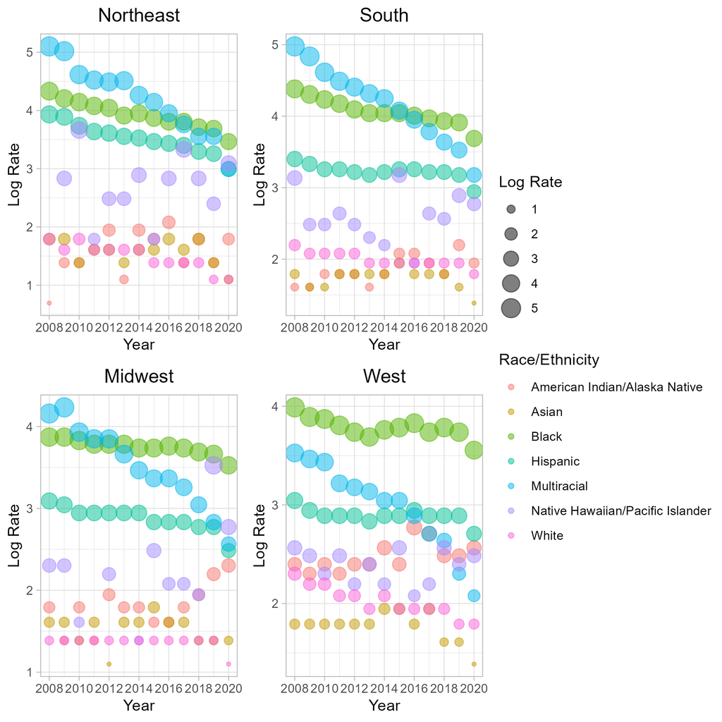

Figure 4: Regional new diagnosis rate (log) by race/ethnicity

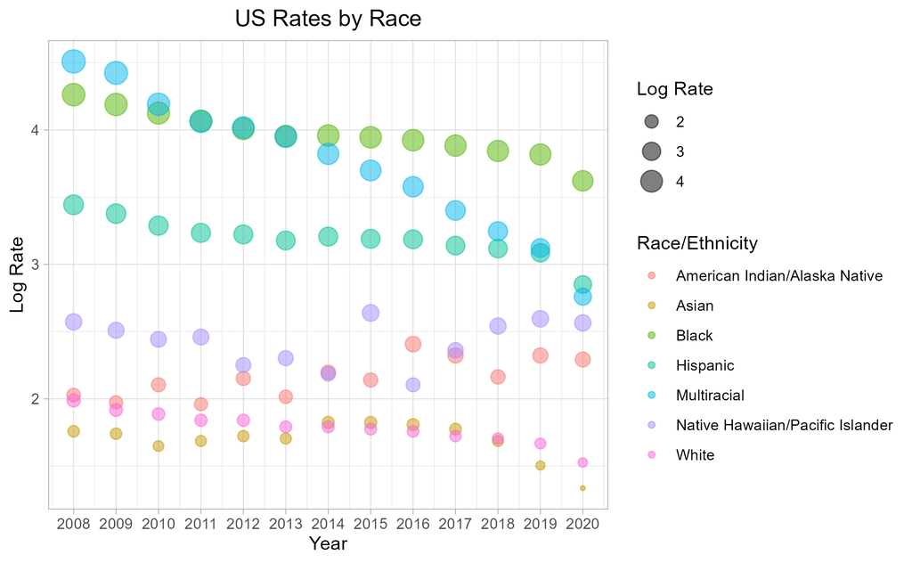

Figure 6 shows national plot of White-Black and White-Hispanic rate differences by year.

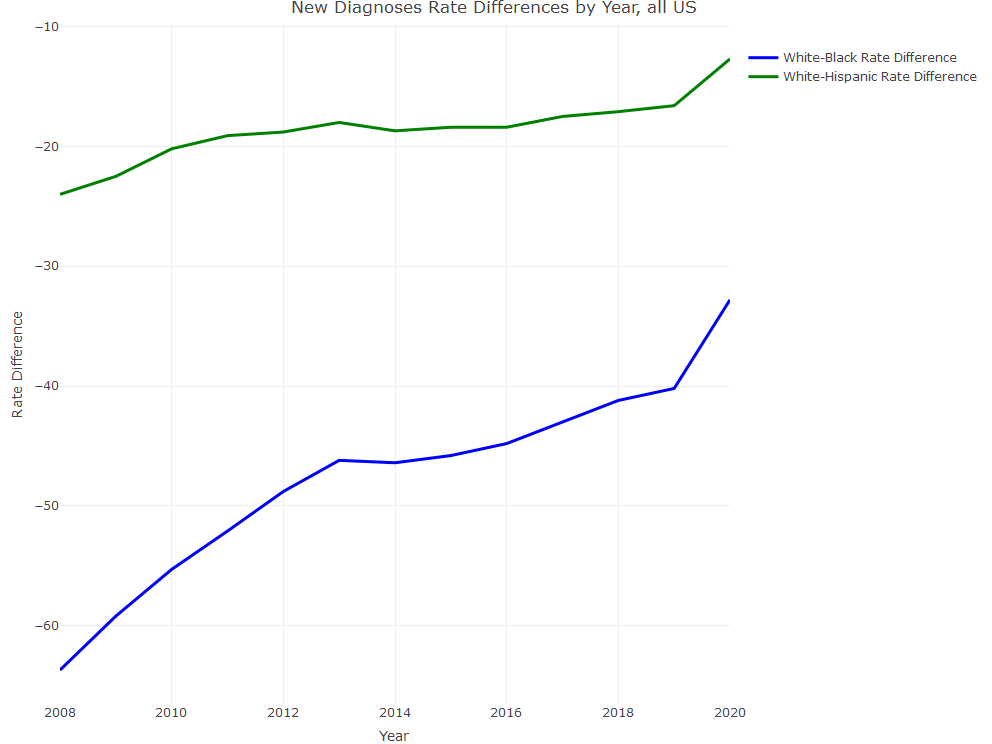

Figure 6: White-Black and White-Hispanic differences in national new diagnosis rate

Table 1 shows a full summary of new diagnosis rates for all US by group.

Table 1: All US New diagnosis Rates

| Year | Overall | Male | Female | Black | White | Hispanic | Asian | American Indian/Alaska Native | Multiracial | Native Hawaiian/Pacific Islander | Age 13-24 | Age 25-34 | Age 35-44 | Age 45-54 | Age 55+ |
| --- | --- | --- | --- | --- | --- | --- | --- | --- | --- | --- | --- | --- | --- | --- | --- |
| 2008 | 18.9 | 29.3 | 8.9 | 71.0 | 7.3 | 31.3 | 5.8 | 7.6 | 90.9 | 13.1 | 16.7 | 30.6 | 29.9 | 21.3 | 5.8 |
| 2009 | 17.7 | 27.9 | 7.9 | 66.0 | 6.8 | 29.3 | 5.7 | 7.2 | 83.5 | 12.3 | 17.1 | 28.9 | 27.5 | 19.5 | 5.3 |
| 2010 | 16.8 | 26.9 | 7.2 | 61.9 | 6.6 | 26.8 | 5.2 | 8.2 | 66.1 | 11.5 | 17.6 | 28.4 | 24.8 | 18.3 | 5.1 |
| 2011 | 16.0 | 25.8 | 6.6 | 58.4 | 6.3 | 25.4 | 5.4 | 7.1 | 58.1 | 11.7 | 17.4 | 27.5 | 22.5 | 17.5 | 4.8 |
| 2012 | 15.6 | 25.5 | 6.1 | 55.1 | 6.3 | 25.1 | 5.6 | 8.6 | 55.6 | 9.5 | 17.4 | 27.9 | 21.0 | 16.8 | 4.6 |
| 2013 | 14.9 | 24.6 | 5.7 | 52.2 | 6.0 | 24.0 | 5.5 | 7.5 | 51.9 | 10.0 | 16.7 | 27.6 | 19.5 | 15.8 | 4.7 |
| 2014 | 15.1 | 25.0 | 5.6 | 52.4 | 6.0 | 24.7 | 6.2 | 9.0 | 45.7 | 8.9 | 17.5 | 29.0 | 19.8 | 15.0 | 4.4 |
| 2015 | 14.9 | 24.8 | 5.4 | 51.7 | 5.9 | 24.3 | 6.2 | 8.5 | 40.4 | 14.0 | 17.4 | 29.6 | 18.9 | 14.7 | 4.2 |
| 2016 | 14.6 | 24.3 | 5.4 | 50.6 | 5.8 | 24.2 | 6.1 | 11.1 | 35.8 | 8.2 | 16.7 | 30.4 | 18.5 | 13.9 | 4.3 |
| 2017 | 14.1 | 23.3 | 5.2 | 48.6 | 5.6 | 23.1 | 5.9 | 10.2 | 30.0 | 10.6 | 16.1 | 29.6 | 17.8 | 13.3 | 4.2 |
| 2018 | 13.7 | 22.7 | 5.1 | 46.7 | 5.5 | 22.6 | 5.4 | 8.7 | 25.7 | 12.7 | 15.3 | 29.3 | 17.4 | 12.7 | 4.0 |
| 2019 | 13.2 | 21.9 | 4.9 | 45.5 | 5.3 | 21.9 | 4.5 | 10.2 | 22.7 | 13.4 | 14.9 | 28.4 | 17.1 | 12.0 | 4.0 |
| 2020 | 10.9 | 18.3 | 3.8 | 37.4 | 4.6 | 17.3 | 3.8 | 9.9 | 15.8 | 13.0 | 11.9 | 24.4 | 14.1 | 9.8 | 3.2 |

## 4.2 Statistical analysis

Table 2 shows a summary of average annual percent change (AAPC) for each subgroup and geographic region.

Table 2: All AAPCs

| Stratification | Geographic Area | AAPC | AAPC_lCI | AAPC_uCI | p-value |
| --- | --- | --- | --- | --- | --- |
| **Overall** |  |  |  |  |  |
| Overall | Midwest | -2.9 | -2.9 | -2.9 | 0.000 |
| Overall | Northeast | -5.7 | -6.7 | -4.8 | 0.000 |
| Overall | South | -4.2 | -5.1 | -3.2 | 0.000 |
| Overall | United States | -4.2 | -5.1 | -3.4 | 0.000 |
| Overall | West | -3.3 | -5.3 | -1.3 | 0.001 |
| **Female** |  |  |  |  |  |
| Female | Midwest | -3.0 | -5.1 | -0.9 | 0.006 |
| Female | Northeast | -6.4 | -7.4 | -5.4 | 0.000 |
| Female | South | -6.2 | -8.0 | -4.3 | 0.000 |
| Female | United States | -6.4 | -7.2 | -5.6 | 0.000 |
| Female | West | -3.0 | -4.9 | -1.1 | 0.005 |
| **Male** |  |  |  |  |  |
| Male | Midwest | -2.5 | -3.2 | -1.8 | 0.000 |
| Male | Northeast | -5.2 | -5.9 | -4.4 | 0.000 |
| Male | South | -2.6 | -3.5 | -1.8 | 0.000 |
| Male | United States | -3.3 | -4.4 | -2.2 | 0.000 |
| Male | West | -2.3 | -3.1 | -1.5 | 0.000 |
| **Age 13-24** |  |  |  |  |  |
| Age 13-24 | Midwest | -2.9 | -4.8 | -1.0 | 0.003 |
| Age 13-24 | Northeast | -4.2 | -5.3 | -3.1 | 0.000 |
| Age 13-24 | South | -3.0 | -4.5 | -1.4 | 0.000 |
| Age 13-24 | United States | -2.7 | -4.0 | -1.3 | 0.000 |
| Age 13-24 | West | -1.0 | -3.6 | 1.7 | 0.477 |
| **Age 25-34** |  |  |  |  |  |
| Age 25-34 | Midwest | -0.4 | -1.9 | 1.1 | 0.580 |
| Age 25-34 | Northeast | -2.6 | -3.5 | -1.6 | 0.000 |
| Age 25-34 | South | -1.6 | -2.9 | -0.4 | 0.010 |
| Age 25-34 | United States | -1.7 | -2.9 | -0.4 | 0.011 |
| Age 25-34 | West | -1.2 | -3.0 | 0.6 | 0.196 |

[output cut: 90 more lines]

Table 3 shows a full summary of annual percent change (APC) for each segment of time within each subgroup and geographic region.

Table 3: All APCs

| Type | Geo | Model | Segment | Segment Start | Segment End | APC | APC 95% LCL | APC 95% UCL | APC Significant | Test Statistic | P-Value |
| --- | --- | --- | --- | --- | --- | --- | --- | --- | --- | --- | --- |
| **Overall** |  |  |  |  |  |  |  |  |  |  |  |
| Overall | Midwest | 3 | 0 | 2008 | 2011 | 0.3 | 0.3 | 0.3 | 1 | 1.244134e+11 | 0.000 |
| Overall | Midwest | 3 | 1 | 2011 | 2014 | -3.9 | -3.9 | -3.9 | 1 | -7.743277e+11 | 0.000 |
| Overall | Midwest | 3 | 2 | 2014 | 2018 | 0.3 | 0.3 | 0.3 | 1 | 1.045010e+11 | 0.000 |
| Overall | Midwest | 3 | 3 | 2018 | 2020 | -11.9 | -11.9 | -11.9 | 1 | -2.444834e+12 | 0.000 |
| Overall | Northeast | 1 | 0 | 2008 | 2018 | -4.2 | -4.7 | -3.7 | 1 | -1.890000e+01 | 0.000 |
| Overall | Northeast | 1 | 1 | 2018 | 2020 | -13.1 | -18.7 | -7.1 | 1 | -4.800000e+00 | 0.001 |
| Overall | South | 2 | 0 | 2008 | 2013 | -4.7 | -5.9 | -3.5 | 1 | -9.600000e+00 | 0.000 |
| Overall | South | 2 | 1 | 2013 | 2018 | -0.7 | -2.5 | 1.1 | 0 | -1.000000e+00 | 0.363 |
| Overall | South | 2 | 2 | 2018 | 2020 | -11.0 | -16.0 | -5.7 | 1 | -5.200000e+00 | 0.004 |
| Overall | United States | 2 | 0 | 2008 | 2011 | -5.6 | -7.9 | -3.3 | 1 | -6.000000e+00 | 0.002 |
| Overall | United States | 2 | 1 | 2011 | 2018 | -1.7 | -2.6 | -0.9 | 1 | -5.400000e+00 | 0.003 |
| Overall | United States | 2 | 2 | 2018 | 2020 | -10.6 | -14.9 | -6.1 | 1 | -5.800000e+00 | 0.002 |
| Overall | West | 2 | 0 | 2008 | 2011 | -6.8 | -12.1 | -1.1 | 1 | -3.100000e+00 | 0.028 |
| Overall | West | 2 | 1 | 2011 | 2018 | -0.1 | -2.1 | 1.9 | 0 | -1.000000e-01 | 0.921 |
| Overall | West | 2 | 2 | 2018 | 2020 | -9.0 | -19.1 | 2.4 | 0 | -2.100000e+00 | 0.094 |
| **Female** |  |  |  |  |  |  |  |  |  |  |  |
| Female | Midwest | 1 | 0 | 2008 | 2013 | -6.7 | -10.9 | -2.2 | 1 | -3.400000e+00 | 0.010 |
| Female | Midwest | 1 | 1 | 2013 | 2020 | -0.3 | -3.1 | 2.5 | 0 | -3.000000e-01 | 0.801 |
| Female | Northeast | 0 | 0 | 2008 | 2020 | -6.4 | -7.4 | -5.4 | 1 | -1.380000e+01 | 0.000 |
| Female | South | 1 | 0 | 2008 | 2011 | -11.0 | -17.8 | -3.6 | 1 | -3.400000e+00 | 0.010 |
| Female | South | 1 | 1 | 2011 | 2020 | -4.5 | -5.9 | -3.1 | 1 | -7.300000e+00 | 0.000 |
| Female | United States | 2 | 0 | 2008 | 2013 | -8.4 | -9.4 | -7.4 | 1 | -2.130000e+01 | 0.000 |
| Female | United States | 2 | 1 | 2013 | 2018 | -1.4 | -2.9 | 0.1 | 0 | -2.400000e+00 | 0.060 |
| Female | United States | 2 | 2 | 2018 | 2020 | -13.1 | -17.1 | -8.9 | 1 | -7.600000e+00 | 0.001 |
| Female | West | 0 | 0 | 2008 | 2020 | -3.0 | -4.9 | -1.1 | 1 | -3.500000e+00 | 0.005 |
| **Male** |  |  |  |  |  |  |  |  |  |  |  |
| Male | Midwest | 1 | 0 | 2008 | 2017 | -0.9 | -1.5 | -0.4 | 1 | -3.800000e+00 | 0.005 |
| Male | Midwest | 1 | 1 | 2017 | 2020 | -7.0 | -9.7 | -4.1 | 1 | -5.600000e+00 | 0.001 |
| Male | Northeast | 1 | 0 | 2008 | 2018 | -4.0 | -4.4 | -3.6 | 1 | -2.270000e+01 | 0.000 |

[output cut: 159 more lines]

Figure 7 shows national plot of new diagnosis Joinpoints for race/ethnicity (Black, White, Hispanic).

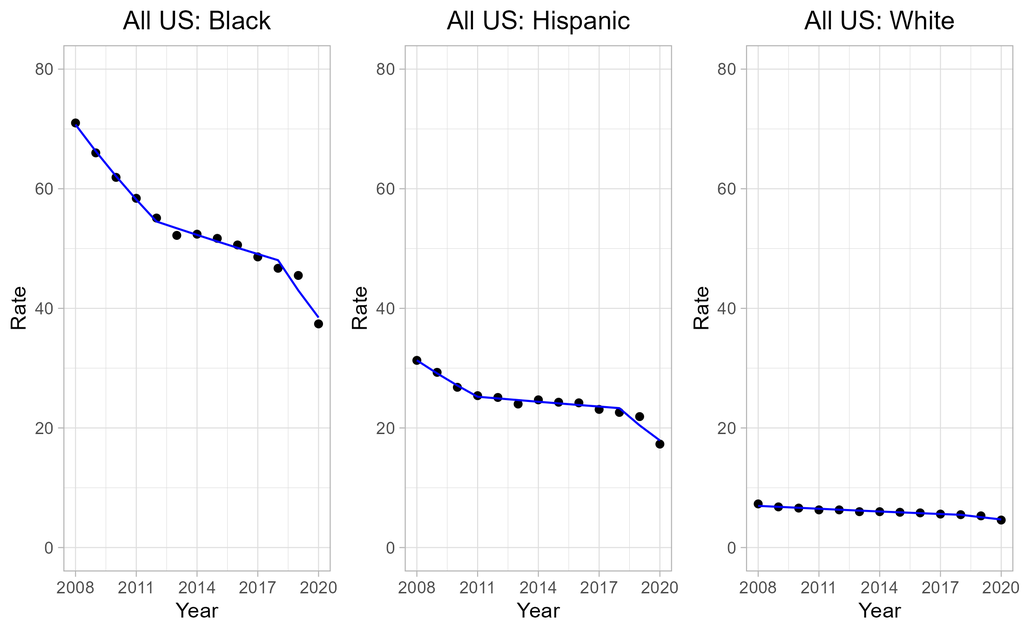

Figure 7: National Joinpoint results comparing Black, White, Hispanic

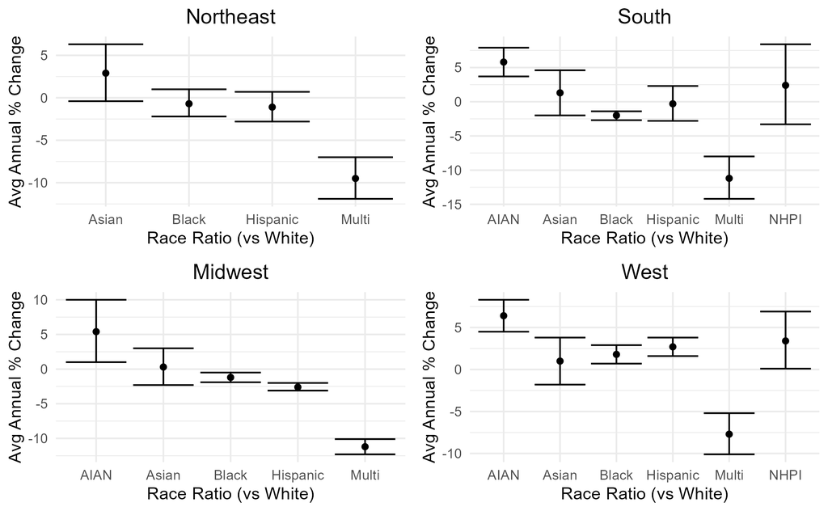

Figure 8: Regional Joinpoint AAPC results by race/ethnicity

Figure 9 shows state-level predictions for Black-White Rate Ratios in 2022 based on Google Trend data for Search Term “HIV”.

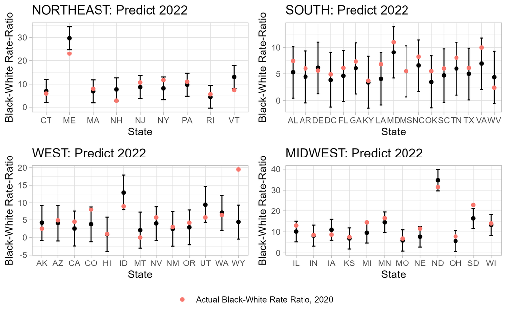

Figure 9: Black-White Rate Ratio Prediction for 2022 based on Google Trend for HIV Search Term

Figure 10 shows state-level predictions for Hispanic-White Rate Ratios in 2022 based on Google Trend data for Search Term “HIV”.

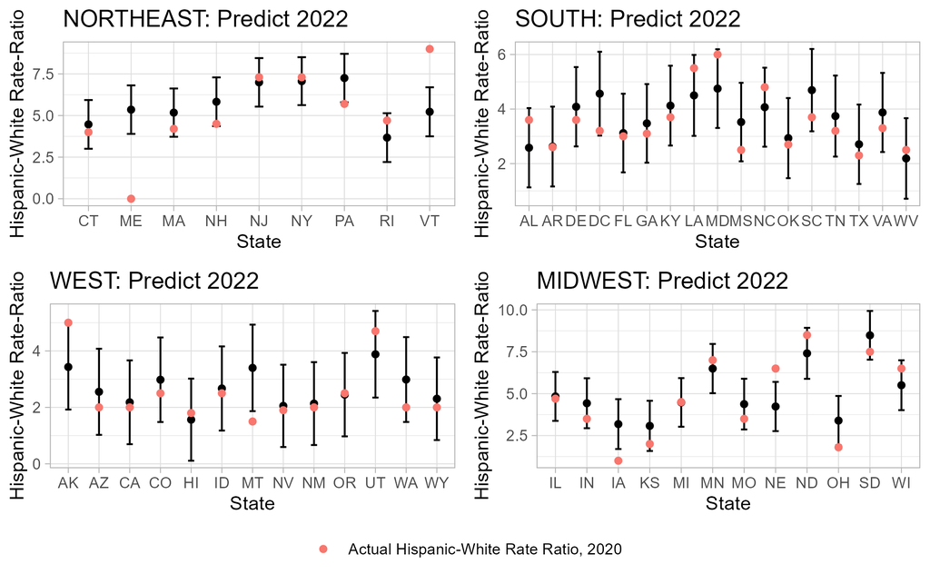

Figure 10: Hispanic-White Rate Ratio Prediction for 2022 based on Google Trend for HIV Search Term

# 5 Discussion

## 5.4 References

Bosh, K. A., Hall, H. I., Eastham, L., & Daskalakis, D. C. (2021). Estimated annual number of HIV infections ─ united states, 1981–2019. *MMWR Morb Mortal Wkly Rep*, *70*(22), 801–806. https://doi.org/https://doi.org/10.15585/mmwr.mm7022a1

Chapin-Bardales, J., Rosenberg, E. S., & Sullivan, P. S. (2017). Trends in racial/ethnic disparities of new AIDS diagnoses in the united states, 1984–2013. *Annals of Epidemiology*, *27*(5), 329–334.e2. https://doi.org/https://doi.org/10.1016/j.annepidem.2017.04.002

Fields, E. L., Copeland, R., & Hopkins, E. (2021). Same script, different viruses: HIV and COVID-19 in US black communities. *The Lancet*, *397*(10279), 1040–1042. https://doi.org/https://doi.org/10.1016/S0140-6736(20)32522-8

McCree, D. H., Williams, A. M., Chesson, H. W., Beer, L., Jeffries, W. L., Lemons, A., … McCray, E. (2019). Changes in disparities in estimated HIV incidence rates among black, hispanic/latino, and white men who have sex with men (MSM) in the united states, 2010–2015. *JAIDS Journal of Acquired Immune Deficiency Syndromes*, *81*(1), 57–62. https://doi.org/https://doi.org/10.1097/QAI.0000000000001977

Sullivan, Patrick S., Giler, R. M., Mouhanna, F., Pembleton, E. S., Guest, J. L., Jones, J., … Siegler, A. J. (2018). Trends in the use of oral emtricitabine/tenofovir disoproxil fumarate for pre-exposure prophylaxis against HIV infection, united states, 2012–2017. *Annals of Epidemiology*, *28*(12), 833–840. https://doi.org/https://doi.org/10.1016/j.annepidem.2018.06.009

Sullivan, Patrick Sean, Woodyatt, C., Koski, C., Pembleton, E., McGuinness, P., Taussig, J., … Sanchez, T. H. (2020). A data visualization and dissemination resource to support HIV prevention and care at the local level: Analysis and uses of the AIDSVu public data resource. *J Med Internet Res*, *22*(10), e23173. https://doi.org/10.2196/23173

Young, S. D., & Zhang, Q. (2018). Using search engine big data for predicting new HIV diagnoses. *PLOS ONE*, *13*(7), e0199527. https://doi.org/https://doi.org/10.1371/journal.pone.0199527